# Ggplot2 Principles

Author

NEXA Cours R 2026

# Ggplot2 Principles

The `ggplot2` library in R is built on the principles of the “Grammar of Graphics,” a framework that defines a structured approach to creating visualizations. Developed by Leland Wilkinson and implemented by Hadley Wickham, the grammar breaks down complex plots into basic, layered components. In this section, we will explore how a ggplot2 plot is built layer-by-layer.

### Load required R libraries

```r
library(ggplot2)
library(tibble)
```

### Build a synthetic dataset

To illustrate the different capabilities of the ggplot2 library we will use a synthetic dataset.

```r
set.seed(123)  # For reproducibility

# Number of patients
nb_patients <- 200

# Generate synthetic data
synthetic_data <- tibble(
  subject_id = paste0("Patient_", 1:nb_patients),
  age = rnorm(nb_patients, mean = 50, sd = 15),
  sex = sample(c("male", "female"),
               size = nb_patients,
               prob = c(0.7, 0.3), replace = TRUE),
  treatment = sample(c("Placebo", "Drug A", "Drug B"),
                     nb_patients, replace = TRUE),
  biomarker_A = rnorm(nb_patients, mean = 5, sd = 1.5),
  # biomarker_B Correlated with biomarker_A
  biomarker_B = biomarker_A * 0.8 + rnorm(nb_patients, mean = 2, sd = 1),
  outcome = 50 + 0.5 * age +
    ifelse(treatment == "Drug A", 10,
           ifelse(treatment == "Drug B", 15, 0)) +
            rnorm(nb_patients, mean = 0, sd = 5))

# Display first few rows of the dataset
head(synthetic_data)
```

```
# A tibble: 6 × 7
  subject_id   age sex    treatment biomarker_A biomarker_B outcome
  <chr>      <dbl> <chr>  <chr>           <dbl>       <dbl>   <dbl>
1 Patient_1   41.6 female Drug A           3.49        5.10    88.4
2 Patient_2   46.5 male   Placebo          5.03        4.67    72.3
3 Patient_3   73.4 female Drug B           3.38        2.76   103.
4 Patient_4   51.1 male   Drug B           6.07        6.74    81.8
5 Patient_5   51.9 male   Drug B           6.63        8.44    86.9
6 Patient_6   75.7 male   Drug A           1.66        3.97    98.1
```

## Introduction

In `ggplot2`, every plot is constructed using a consistent set of elements: data, aesthetic mappings (like `x`, `y`, color), and geometric objects (such as points, lines, or bars). Layers can then be added to control scales, facets, and statistical transformations, allowing for powerful customization and clarity in displaying data relationships. The grammar-based structure of `ggplot2` enables flexibility in combining these elements, making it easy to build clear, complex plots in a standardized, reproducible way. `ggplot2` emphasizes “tidy” data, where each variable is a column and each observation is a row, allowing seamless integration with the broader Tidyverse toolkit.

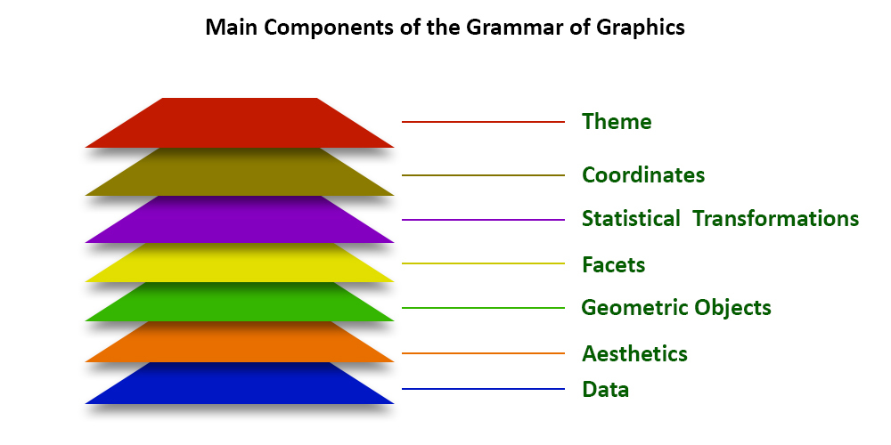